# EpiCompare Report

Mar-17-2022

EpiCompare compares epigenetic datasets for quality control and benchmarking purposes. The report consists of three sections:

1. **General Metrics:** Metrics on peaks (percentage of blacklisted and non-standard peaks, and peak widths) and fragments (duplication rate) of samples.
2. **Peak Overlap:** Percetnage and statistical significance of overlapping and non-overlapping peaks. Also includes upset plot.
3. **Functional Annotation:** Functional annotation (ChromHMM, ChIPseeker and enrichment analysis) of peaks. Also includes peak enrichment around TSS.

##### Input Datasets

- Reference peakfile: encode
- Total of 3 peak files:

```
## [1] "File1: CnT"
## [1] "File2: CnR"
## [1] "File3: encode"
```

##### Code

```r
EpiCompare(peakfiles = list(CnT, CnR, encode),
           blacklist = blacklist,
           picard_files = list(CnT, CnR),
           reference = encode,
           stat_plot = TRUE,
           chrmHMM_plot = TRUE,
           chrmHMM_annotation = "K562",
           chipseeker_plot = TRUE,
           enrichment_plot = TRUE,
           interact = FALSE,
           save_output = TRUE,
           output_dir = "/Users/serachoi/Documents/EpiCompare")
```

## 1. General Metrics

### Peak Information

Column Description:

- PeakN before tidy: Total number of peaks including those blacklisted and those in non-standard chromosomes.
- Blacklisted peaks removed (%): Percentage of blacklisted peaks in samples. E.g. [ENCODE hg19 blacklist](https://www.encodeproject.org/files/ENCFF000KJP/) includes regions in the hg19 genome that have anomalous and/or unstructured signals independent of the cell-line or experiment.
- Non-standard peaks removed (%): Percentage of peaks in non-standard and/or mitochondrial chromosomes. Identified using `BRGenomics::tidyChromosomes()`.
- PeakN after tidy: Total number of peaks after removing those in blacklisted regions and non-standard chromosomes.

**NB**: EpiCompare uses *filtered* peakfiles (i.e. datasets after removing peaks in blacklisted regions and non-standard chromosomes)

[output not shown]

### Fragment Information

Metrics on fragments is shown only if Picard summary is provided. See [manual](https://neurogenomics.github.io/EpiCompare/) for help.

Column Description:

- Mapped_Fragments: Number of mapped read pairs in the file.
- Duplication_Rate: Percentage of mapped sequence that is marked as duplicate.
- Unique_Fragments: Number of mapped sequence that is not marked as duplicate.

|  | Mapped_Fragments | Duplication_Rate | Unique_Fragments |
| --- | --- | --- | --- |
| CnT | 2293087 | 20.18 | 1830390 |
| CnR | 5523031 | 7.30 | 5120026 |

### Peak widths

Distribution of peak widths in samples

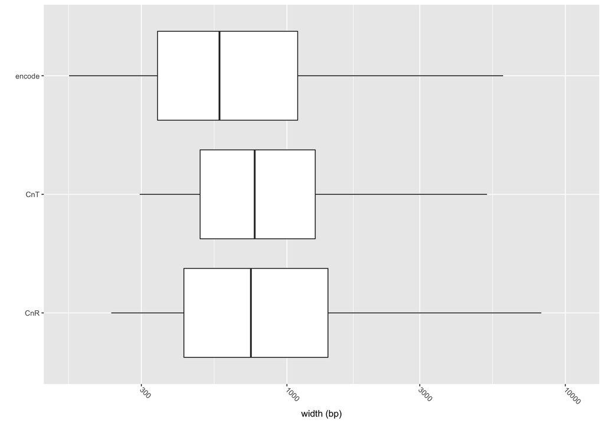

## 2. Peak Overlap

### Percentage Overlap

Percentage of overlapping peaks between samples. Hover over heatmap for percentage values.

N.B. How to interpret heatmap: [Samples in x-axis of heatmap] peaks in [Samples in y-axis of heatmap] peaks

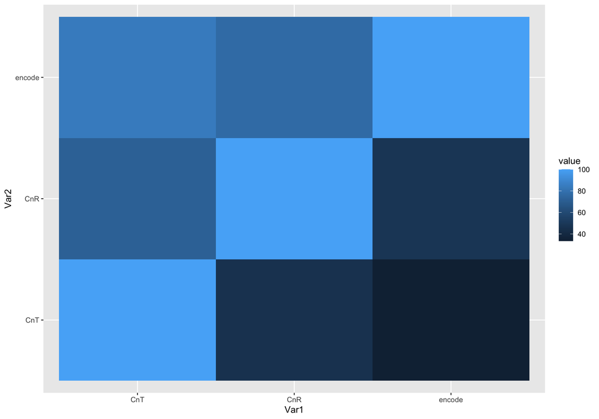

### Upset Plot

Upset plot of overlapping peaks between samples. See [here](https://jokergoo.github.io/ComplexHeatmap-reference/book/upset-plot.html) on how to interpret the plot.

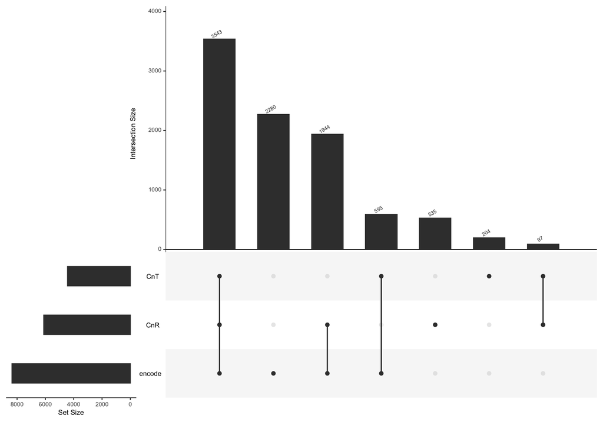

quartz_off_screen 2

### Statistical Significance

Depending on the format of the reference file, EpiCompare outputs different plots:

- Reference dataset has BED6+4 format (peakcalling performed with MACS2): EpiCompare generates paired boxplot per sample showing the distribution of -log10(q-value) of reference peaks that are overlapping and non-overlapping with the sample dataset.
- Reference dataset does not have BED6+4 format: EpiCompare generates a barplot of percentage of overlapping sample peaks with the reference, coloured by statistical significance (adjusted p-value) of the overlap.

**Reference peakfile: encode**

Keys:

- Overlap: Sample peaks in Reference peaks
- Unique: Sample peaks not in Reference peaks

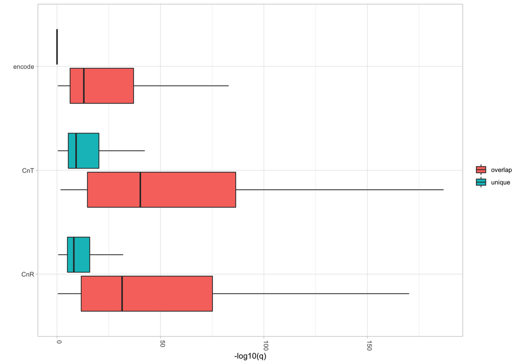

## 3. Functional Annotation

### 3.1 ChromHMM

[ChromHMM](http://compbio.mit.edu/ChromHMM/#:~:text=ChromHMM%20is%20software%20for%20learning%20and%20characterizing%20chromatin%20states.&text=ChromHMM%20is%20based%20on%20a,one%20or%20more%20cell%20types.) annotates and characterises peaks into different chromatin states. ChromHMM annotations used in EpiCompare were obtained from [here](http://hgdownload.cse.ucsc.edu/goldenPath/hg19/encodeDCC/wgEncodeBroadHmm/).

- Cell-type annotation file used in this analysis: K562

#### All samples

ChromHMM annotation of individual samples.

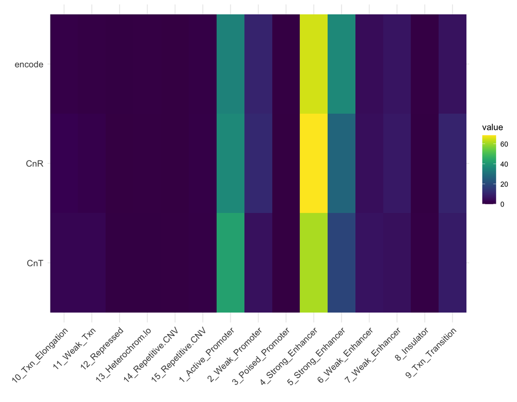

#### **Overlap**: Sample peaks in Reference peaks

Percentage of Sample peaks found in Reference peaks (**Reference peakfile: encode**)

|  | Percentage |
| --- | --- |
| CnT | 84.1 |
| CnR | 77.0 |
| encode | 100.0 |

ChromHMM annotation of sample peaks found in reference peaks.

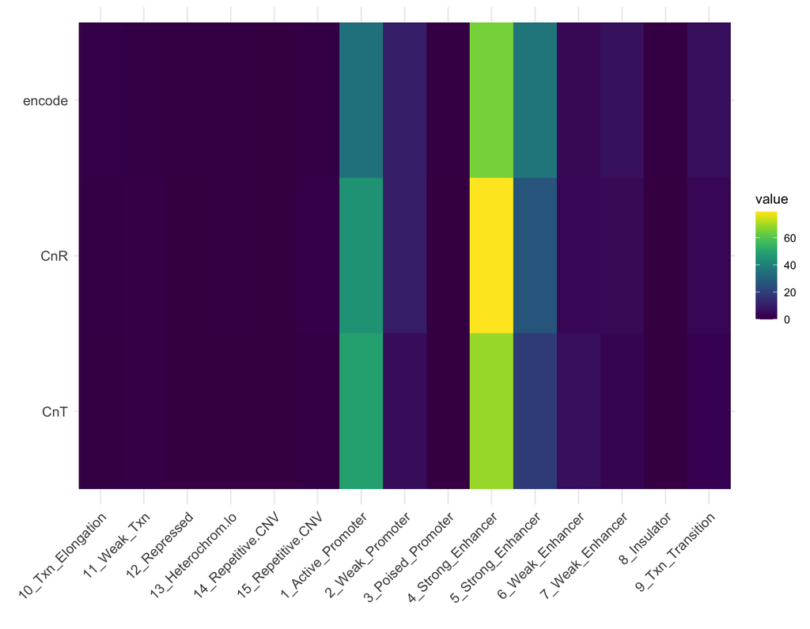

#### **Overlap**: Reference peaks in Sample peaks

Percentage of Reference peaks found in Sample peaks (**Reference peakfile: encode**)

|  | Percentage |
| --- | --- |
| CnT | 33.5 |
| CnR | 48.1 |
| encode | 100.0 |

ChromHMM annotation of reference peaks found in sample peaks.

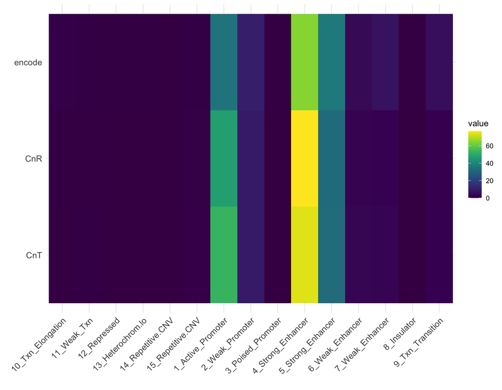

#### **Unique**: Sample peaks not in Reference peaks

Percentage of sample peaks not found in reference peaks (**Reference peakfile: encode**)

|  | Percentage |
| --- | --- |
| CnT | 15.9 |
| CnR | 23.0 |
| encode | 0.0 |

ChromHMM annotation of sample peaks not found in reference peaks.

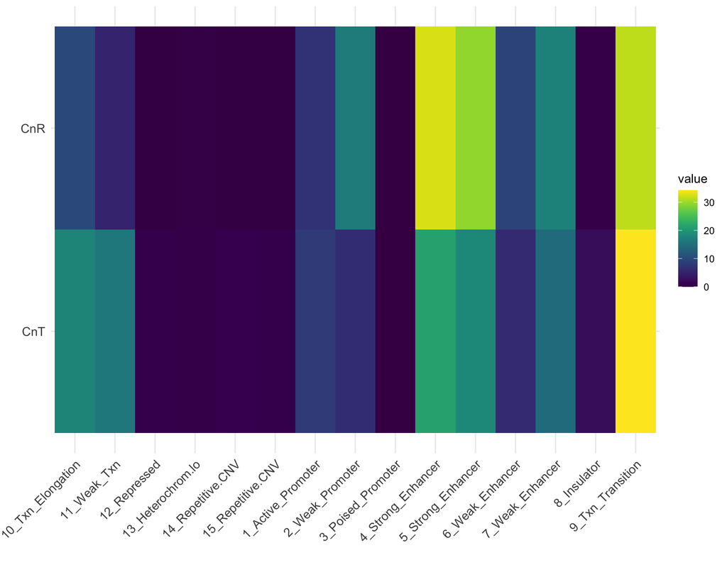

#### **Unique**: Reference peaks not in Sample peaks

Percentage of reference peaks not found in sample peaks (**Reference peakfile: encode**)

|  | Percentage |
| --- | --- |
| CnT | 66.5 |
| CnR | 51.9 |
| encode | 0.0 |

ChromHMM annotation of reference peaks not found in sample peaks.

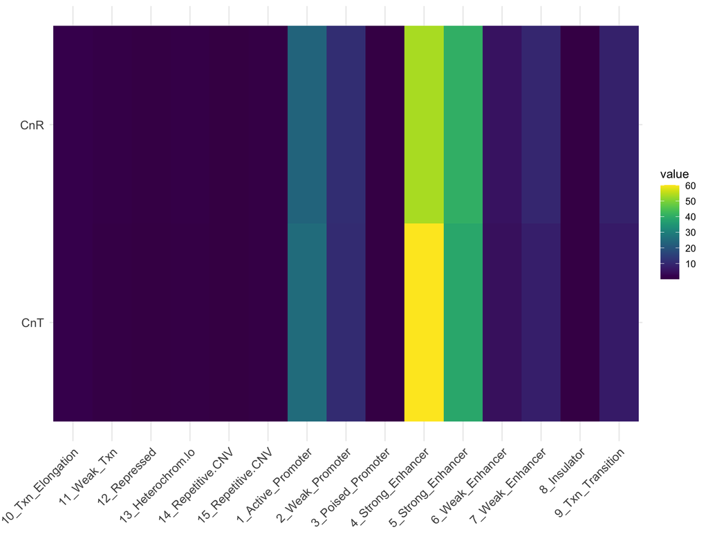

### 3.2 ChIPseeker

EpiCompare uses `ChIPseeker::annotatePeak()` to annotate peaks with the nearest gene and genomic regions where the peak is located. The peaks are annotated with [genes](http://bioconductor.org/packages/release/data/annotation/html/TxDb.Hsapiens.UCSC.hg19.knownGene.html) taken from the annotations of human genome hg19 provided by Bioconductor.

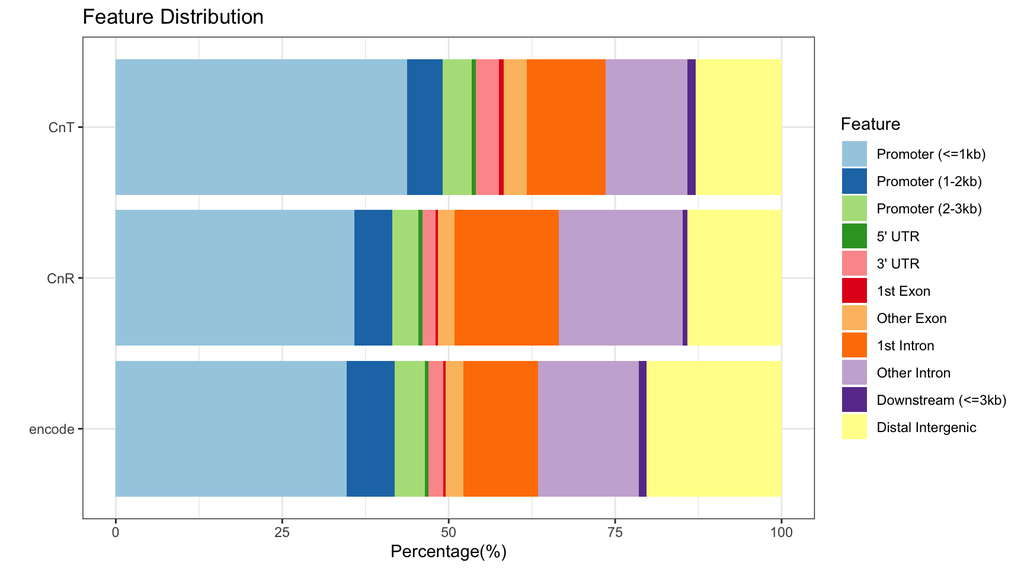

### 3.3 Functional Enrichment Analysis

EpiCompare performs KEGG pathway and GO enrichment analysis using `clusterProfiler`. `ChIPseeker::annotatePeak()` is first used to assign peaks to nearest genes. Biological themes amongst the genes are identified using ontologies (KEGG and GO). The peaks are annotated with [genes](http://bioconductor.org/packages/release/data/annotation/html/TxDb.Hsapiens.UCSC.hg19.knownGene.html) taken from the annotations of human genome hg19 provided by Bioconductor.

#### KEGG

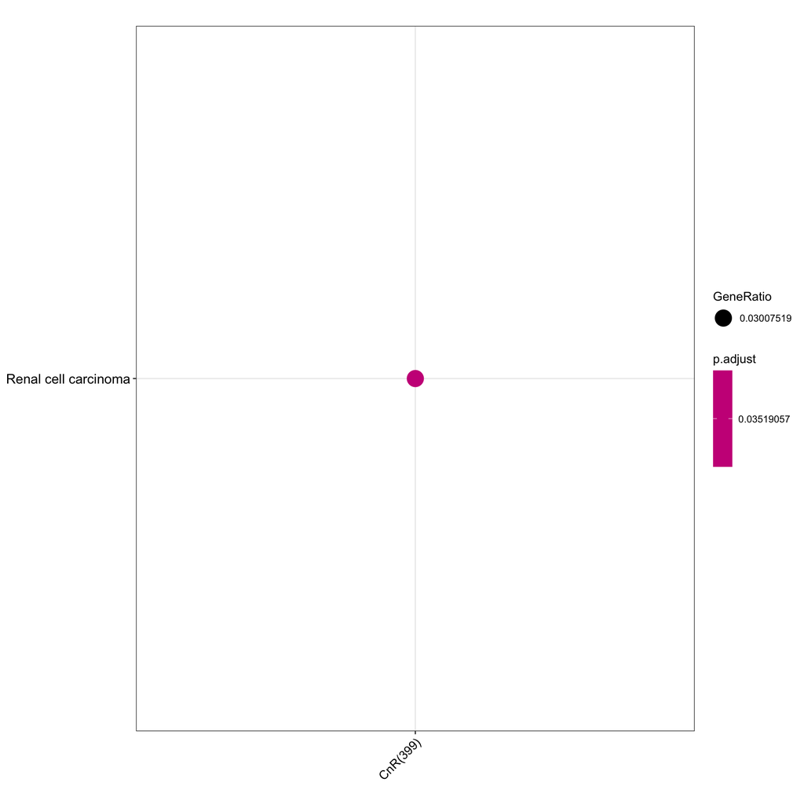

#### GO

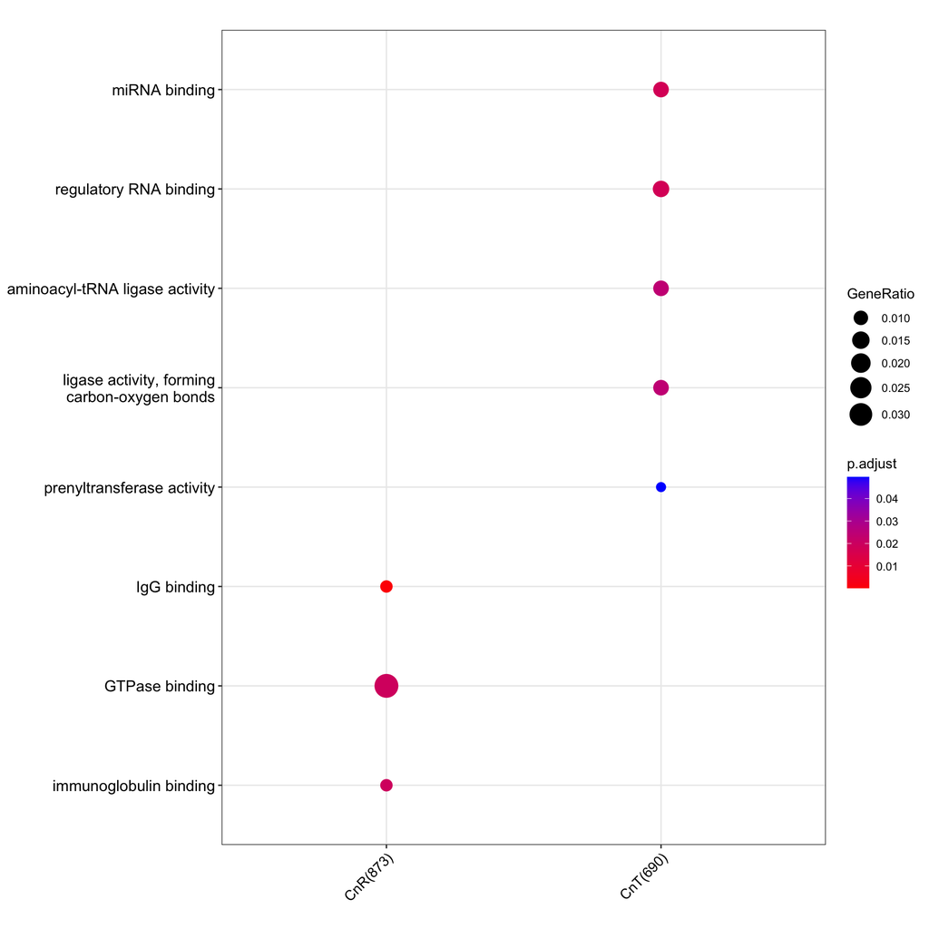

### 3.4 Peak Frequency around TSS

[output not shown]

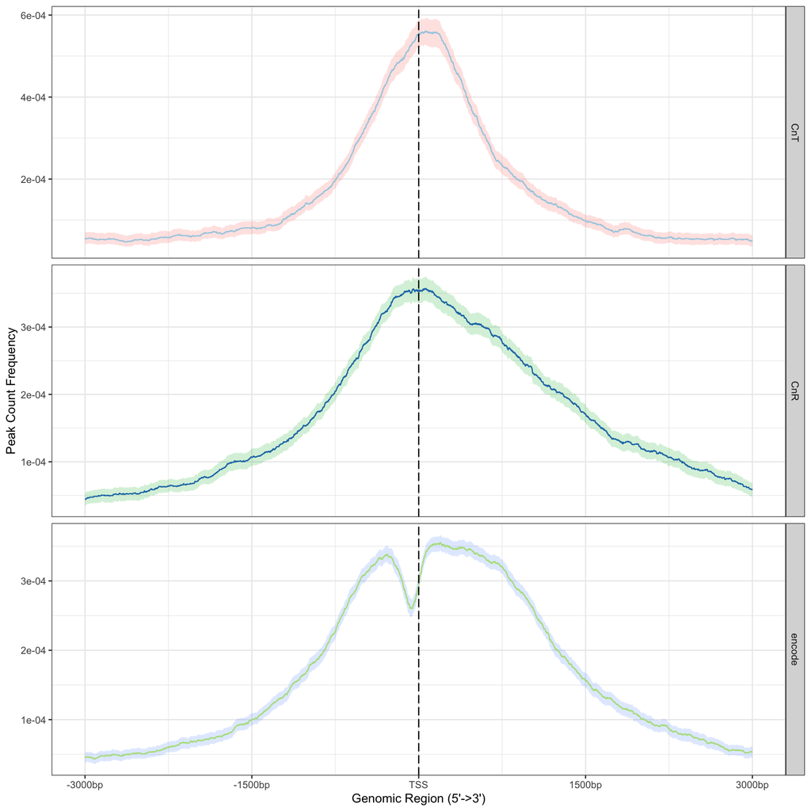